[figure not shown]

# Importing required librariers and functions

```python
# For autoreloading modules
%load_ext autoreload
%autoreload 2
# For notebook plotting
%matplotlib inline

# Standard libraries
import os
import numpy as np
import pandas as pd
import gc
import time

import random
random.seed(42)

import warnings
warnings.filterwarnings("ignore", category=DeprecationWarning)
pd.options.mode.chained_assignment = None  # default='warn' for SettingWithCopyWarning at feature engg.

# Visualization
import matplotlib.pyplot as plt
import seaborn as sns
from IPython.display import display

# Machine Learning
import sklearn
from sklearn import metrics
from scipy.cluster import hierarchy as hc

def reduce_mem_usage(df):
    # iterate through all the columns of a dataframe and modify the data type
    #   to reduce memory usage.
    start_mem = df.memory_usage().sum() / 1024**2
    print('Memory usage of dataframe is {:.2f} MB'.format(start_mem))

    for col in df.columns:
        col_type = df[col].dtype

        if col_type != object:
            c_min = df[col].min()
            c_max = df[col].max()
            if str(col_type)[:3] == 'int':
                if c_min > np.iinfo(np.int8).min and c_max < np.iinfo(np.int8).max:
                    df[col] = df[col].astype(np.int8)
                elif c_min > np.iinfo(np.int16).min and c_max < np.iinfo(np.int16).max:
                    df[col] = df[col].astype(np.int16)
                elif c_min > np.iinfo(np.int32).min and c_max < np.iinfo(np.int32).max:
                    df[col] = df[col].astype(np.int32)
                elif c_min > np.iinfo(np.int64).min and c_max < np.iinfo(np.int64).max:
                    df[col] = df[col].astype(np.int64)
            else:
                if c_min > np.finfo(np.float16).min and c_max < np.finfo(np.float16).max:
                    df[col] = df[col].astype(np.float16)
                elif c_min > np.finfo(np.float32).min and c_max < np.finfo(np.float32).max:
                    df[col] = df[col].astype(np.float32)
                else:
                    df[col] = df[col].astype(np.float64)

    end_mem = df.memory_usage().sum() / 1024**2
    print('Memory usage after optimization is: {:.2f} MB'.format(end_mem))
    print('Decreased by {:.1f}%'.format(100 * (start_mem - end_mem) / start_mem))

    return df
```

# Loading datasets

```python
train=pd.read_csv('train_V2.csv')
test=pd.read_csv('test_V2.csv')
```

```python
train.info()
```

```
<class 'pandas.core.frame.DataFrame'>
RangeIndex: 4446966 entries, 0 to 4446965
Data columns (total 29 columns):
Id                 object
groupId            object
matchId            object
assists            int64
boosts             int64
damageDealt        float64
DBNOs              int64
headshotKills      int64
heals              int64
killPlace          int64
killPoints         int64
kills              int64
killStreaks        int64
longestKill        float64
matchDuration      int64
matchType          object
maxPlace           int64
numGroups          int64
rankPoints         int64
revives            int64
rideDistance       float64
roadKills          int64
swimDistance       float64
teamKills          int64
vehicleDestroys    int64
walkDistance       float64
weaponsAcquired    int64
winPoints          int64
winPlacePerc       float64
dtypes: float64(6), int64(19), object(4)
memory usage: 983.9+ MB
```

```python
# Import dataset
train1 = reduce_mem_usage(train)
test1 =reduce_mem_usage(test)
```

```
Memory usage of dataframe is 983.90 MB
Memory usage after optimization is: 288.39 MB
Decreased by 70.7%
Memory usage of dataframe is 413.18 MB
Memory usage after optimization is: 121.74 MB
Decreased by 70.5%
```

```python
train1.info()
```

```
<class 'pandas.core.frame.DataFrame'>
RangeIndex: 4446966 entries, 0 to 4446965
Data columns (total 29 columns):
Id                 object
groupId            object
matchId            object
assists            int8
boosts             int8
damageDealt        float16
DBNOs              int8
headshotKills      int8
heals              int8
killPlace          int8
killPoints         int16
kills              int8
killStreaks        int8
longestKill        float16
matchDuration      int16
matchType          object
maxPlace           int8
numGroups          int8
rankPoints         int16
revives            int8
rideDistance       float16
roadKills          int8
swimDistance       float16
teamKills          int8
vehicleDestroys    int8
walkDistance       float16
weaponsAcquired    int16
winPoints          int16
winPlacePerc       float16
dtypes: float16(6), int16(5), int8(14), object(4)
memory usage: 288.4+ MB
```

```python
train=train1.copy()
test=test1.copy()
```

# Null value check

```python
train.isnull().any()
```

```
Id                 False
groupId            False
matchId            False
assists            False
boosts             False
damageDealt        False
DBNOs              False
headshotKills      False
heals              False
killPlace          False
killPoints         False
kills              False
killStreaks        False
longestKill        False
matchDuration      False
matchType          False
maxPlace           False
numGroups          False
rankPoints         False
revives            False
rideDistance       False
roadKills          False
swimDistance       False
teamKills          False
vehicleDestroys    False
walkDistance       False
weaponsAcquired    False
winPoints          False
winPlacePerc        True
dtype: bool
```

```python
test.isnull().any()
```

```
Id                 False
groupId            False
matchId            False
assists            False
boosts             False
damageDealt        False
DBNOs              False
headshotKills      False
heals              False
killPlace          False
killPoints         False
kills              False
killStreaks        False
longestKill        False
matchDuration      False
matchType          False
maxPlace           False
numGroups          False
rankPoints         False
revives            False
rideDistance       False
roadKills          False
swimDistance       False
teamKills          False
vehicleDestroys    False
walkDistance       False
weaponsAcquired    False
winPoints          False
dtype: bool
```

> As we have seen column winPlacePerc contain True for null value check..So, lets see which player has NULL in winPlacePerc

```python
train[train['winPlacePerc'].isnull()]
```

|  | Id | groupId | matchId | assists | boosts | damageDealt | DBNOs | headshotKills | heals | killPlace | ... | revives | rideDistance | roadKills | swimDistance | teamKills | vehicleDestroys | walkDistance | weaponsAcquired | winPoints | winPlacePerc |
| --- | --- | --- | --- | --- | --- | --- | --- | --- | --- | --- | --- | --- | --- | --- | --- | --- | --- | --- | --- | --- | --- |
| 2744604 | f70c74418bb064 | 12dfbede33f92b | 224a123c53e008 | 0 | 0 | 0.0 | 0 | 0 | 0 | 1 | ... | 0 | 0.0 | 0 | 0.0 | 0 | 0 | 0.0 | 0 | 0 | NaN |

1 rows × 29 columns

```python
train.drop(2744604, inplace = True)
print("Null value is dropped")
```

```
Null value is dropped
```

# Current modes

accroding to [PUBG Wiki](http://pubg.gamepedia.com/Game_Modes)

Game mode Descrition : https://pubg.gamepedia.com/Game_Modes

### Basic mode

- **`sqaud`** : Squad is a gameplay type where players are organized into teams which are then pitted against each other. This is distinct from the classic Free For All (FFA) gameplay mode, where players are free to kill whomever they wish.SQUAD, a game mode where you can team up in groups of 2, 3 or 4 players, or if you prefer, you can still play solo and take on everyone alone in the match.

Note: No matter the size of your party when you enter a match, you'll be matched with teams of 4.

- **`sqaud-fpp`** : Squad FPP(First Person Perspective) is based around your normal Squad game mode (as read above), but instead of being in 3rd person this is strictly in 1st person.
- **`duo`** : For this game mode, you will be paired up with another individual and will compete to be the last ones alive.
- **`duo-fpp`** : Duo FPP is based around your normal Duo game mode (as read above), but instead of being in 3rd person this is strictly in 1st person.
- **`solo`** : The classic game mode. Complete free for all, kill everyone, be the last one alive. Solo, a game mode where you spawn into the world alone and you just rely on your own tactics and skill to push you to the end and be the last player alive.
- **`solo-fpp`** : Solo FPP is based around your normal Solo game mode (as read above), but instead of being in 3rd person this is strictly in 1st person.
- **`Normal matches`** : I checked with the API's documentation, and it appears that games prepended with "normal" are custom games (such as faceit games, Zombies and War(arcade) )

### Event mode

event modes are PUBG’s version of custom games available to all players.

- **`flare (flare gun)`** : Flare Gun can be obtained. A flare gun is a kind of signal that shoots toward the sky. It is a special firearm that supplies a special package (Care Package) when the airplane is deployed to that position when in use. (Flare gun mode)[https://www.dbltap.com/posts/6176131-new-pubg-event-mode-flare-gun-to-last-10-days]
- **`crash (Crash Carnage)`** : " Road scary is the subject of this week's event mode, where fuel and fire are king." In Crashcanage, there are no firearms. You have to concentrate on driving skills that can move the Duo to the final round. In this event, the circle moves quite fast, so it quickly crashes on the way to the loot, the vehicle, and the warrior glory of the road. " i.e. It means to win only with a melee weapon without a gun.

Sources of information :

- [Flare gun mode](https://www.dbltap.com/posts/6176131-new-pubg-event-mode-flare-gun-to-last-10-days)
- [Flare gun gameplay video](https://www.youtube.com/watch?v=xGvTUUj3F-I)
- [Crash carnage](https://comicbook.com/gaming/2018/10/04/pubg-event-mode-crash-carnage-/)
- [Crash carnage gameplay video](https://www.youtube.com/watch?v=5rbIhg6mNPI)

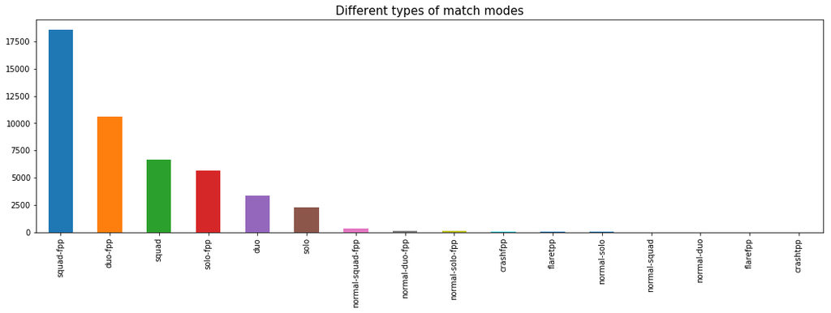

```python
#Different types of matchs
plt.figure(figsize = (18, 5))
train.groupby('matchId')['matchType'].first().value_counts().plot.bar()
plt.title("Different types of match modes",fontsize=15)
```

```python
train.groupby('matchId')['matchType'].first().value_counts()
```

```
squad-fpp           18576
duo-fpp             10620
squad                6658
solo-fpp             5678
duo                  3356
solo                 2297
normal-squad-fpp      358
normal-duo-fpp        158
normal-solo-fpp        96
crashfpp               73
flaretpp               29
normal-solo            23
normal-squad           16
normal-duo             12
flarefpp                9
crashtpp                5
Name: matchType, dtype: int64
```

## Match Duration

This variable indicates how long the game took. So important variables affecting the variable (like walkDistance and ride distance)

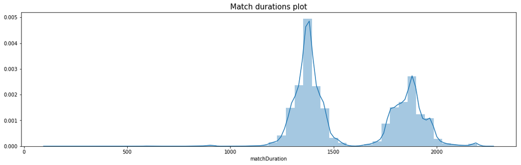

```python
import warnings
warnings.filterwarnings("ignore", category=FutureWarning)#kdeplot..remove to know futurewarning if error comes

plt.figure(figsize = (18, 5))
sns.distplot(train['matchDuration'])
plt.title("Match durations plot",fontsize=15)
```

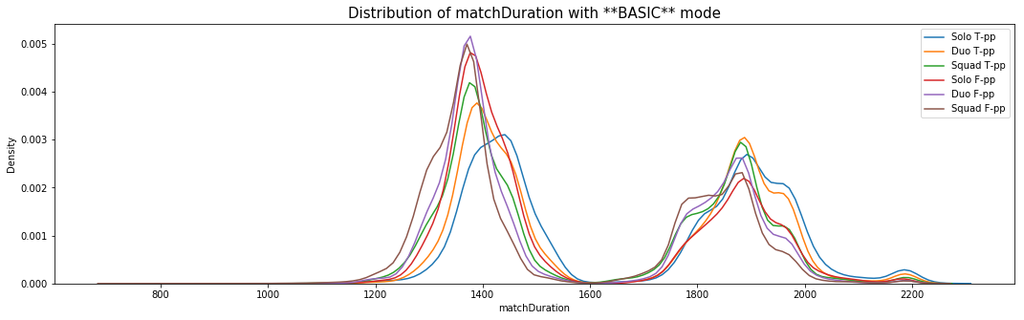

```python
plt.figure(figsize=(18,5))
sns.kdeplot(train.loc[train['matchType']=='solo','matchDuration'], label='Solo T-pp')
sns.kdeplot(train.loc[train['matchType']=='duo','matchDuration'], label='Duo T-pp')
sns.kdeplot(train.loc[train['matchType']=='squad','matchDuration'], label='Squad T-pp')
sns.kdeplot(train.loc[train['matchType']=='solo-fpp','matchDuration'], label='Solo F-pp')
sns.kdeplot(train.loc[train['matchType']=='duo-fpp','matchDuration'], label='Duo F-pp')
sns.kdeplot(train.loc[train['matchType']=='squad-fpp','matchDuration'], label='Squad F-pp')

# Labeling of plot
plt.xlabel('matchDuration'); plt.ylabel('Density');
plt.title('Distribution of matchDuration with **BASIC** mode',fontsize=15)
```

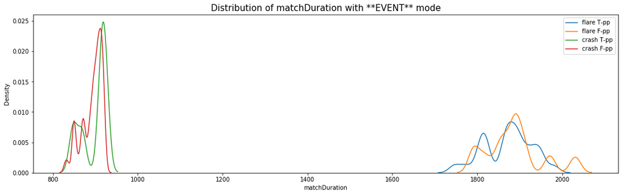

```python
plt.figure(figsize=(18,5))

sns.kdeplot(train.loc[train['matchType']=='flaretpp','matchDuration'], label='flare T-pp')
sns.kdeplot(train.loc[train['matchType']=='flarefpp','matchDuration'], label='flare F-pp')
sns.kdeplot(train.loc[train['matchType']=='crashtpp','matchDuration'], label='crash T-pp')
sns.kdeplot(train.loc[train['matchType']=='crashfpp','matchDuration'], label='crash F-pp')

# Labeling of plot
plt.xlabel('matchDuration'); plt.ylabel('Density'); plt.title('Distribution of matchDuration with **EVENT** mode',fontsize=15)
```

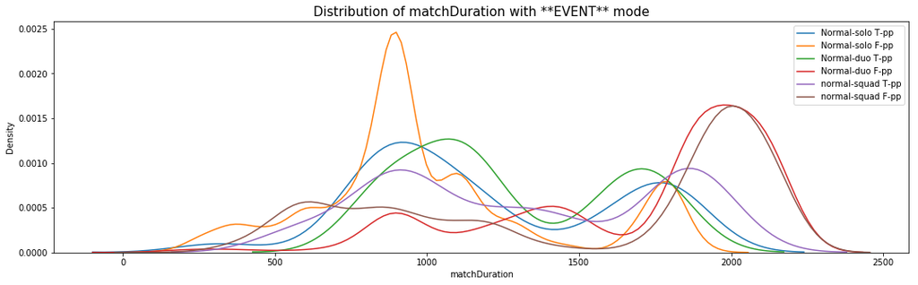

```python
plt.figure(figsize=(18,5))

sns.kdeplot(train.loc[train['matchType']=='normal-solo','matchDuration'], label='Normal-solo T-pp')
sns.kdeplot(train.loc[train['matchType']=='normal-solo-fpp','matchDuration'], label='Normal-solo F-pp')

sns.kdeplot(train.loc[train['matchType']=='normal-duo','matchDuration'], label='Normal-duo T-pp')
sns.kdeplot(train.loc[train['matchType']=='normal-duo-fpp','matchDuration'], label='Normal-duo F-pp')

sns.kdeplot(train.loc[train['matchType']=='normal-squad','matchDuration'], label='normal-squad T-pp')
sns.kdeplot(train.loc[train['matchType']=='normal-squad-fpp','matchDuration'], label='normal-squad F-pp')

# Labeling of plot
plt.xlabel('matchDuration'); plt.ylabel('Density'); plt.title('Distribution of matchDuration with **EVENT** mode',fontsize=15)
```

The above 3 plots coclude that-

- In Basic mode, there are 2 peeks ..means 1st peak match is shorter then 2nd peak.
- In Event mode, peaks are orignated depends on type of match being played-

> Crash tpp/fpp are having sort time duration compare to Flare tpp/fpp.

> Arcade mode or zombie mode are played with diffrent time duration

The match duration is relevant to winning the game.. like high match duration means more time of survivel.

# Players in a team

```python
agg = train.groupby(['groupId']).size().to_frame('players_in_team')
train = train.merge(agg, how='left', on=['groupId'])
```

```python
morethen_4_plyrs_df=train.loc[train['players_in_team']>4]
morethen_4_plyrs_df.head()
```

|  | Id | groupId | matchId | assists | boosts | damageDealt | DBNOs | headshotKills | heals | killPlace | ... | rideDistance | roadKills | swimDistance | teamKills | vehicleDestroys | walkDistance | weaponsAcquired | winPoints | winPlacePerc | players_in_team |
| --- | --- | --- | --- | --- | --- | --- | --- | --- | --- | --- | --- | --- | --- | --- | --- | --- | --- | --- | --- | --- | --- |
| 5 | ff79c12f326506 | 289a6836a88d27 | bac52627a12114 | 0 | 0 | 100.0000 | 1 | 1 | 0 | 44 | ... | 0.0 | 0 | 0.00000 | 0 | 0 | 34.6875 | 1 | 0 | 0.036987 | 10 |
| 6 | 95959be0e21ca3 | 2c485a1ad3d0f1 | a8274e903927a2 | 0 | 0 | 0.0000 | 0 | 0 | 0 | 96 | ... | 0.0 | 0 | 0.00000 | 0 | 0 | 13.5000 | 1 | 1497 | 0.000000 | 6 |
| 10 | 2b574d43972813 | c549efede67ad3 | 2dd6ddb8320fc1 | 0 | 0 | 28.3750 | 0 | 0 | 0 | 75 | ... | 0.0 | 0 | 0.00000 | 0 | 0 | 868.5000 | 9 | 0 | 0.392822 | 5 |
| 16 | 62f2f0917d84b2 | f61b698274d9f5 | 1d6cfe0f6f23b0 | 0 | 2 | 81.6875 | 1 | 0 | 14 | 25 | ... | 520.0 | 0 | 0.00000 | 0 | 0 | 3674.0000 | 7 | 0 | 0.730957 | 5 |
| 19 | 71cbdbc3b263e5 | 7b61f74b51906c | a329ac99449ad7 | 0 | 1 | 65.2500 | 0 | 0 | 1 | 48 | ... | 0.0 | 0 | 20.84375 | 0 | 0 | 3310.0000 | 3 | 1479 | 0.931152 | 5 |

5 rows × 30 columns

```python
morethen_4_plyrs_df.loc[morethen_4_plyrs_df['matchType']=='solo'].head()
```

|  | Id | groupId | matchId | assists | boosts | damageDealt | DBNOs | headshotKills | heals | killPlace | ... | rideDistance | roadKills | swimDistance | teamKills | vehicleDestroys | walkDistance | weaponsAcquired | winPoints | winPlacePerc | players_in_team |
| --- | --- | --- | --- | --- | --- | --- | --- | --- | --- | --- | --- | --- | --- | --- | --- | --- | --- | --- | --- | --- | --- |
| 846 | 0df7c355497d77 | 325464bcf4c846 | f3a64f99badeca | 0 | 0 | 0.0 | 0 | 0 | 0 | 5 | ... | 0.0 | 0 | 0.0 | 0 | 0 | 0.0 | 6 | 0 | 0.0 | 19 |
| 1357 | 72f70c6c074ca9 | da042db555b932 | f3c5fa51aacb95 | 0 | 0 | 723.0 | 0 | 0 | 0 | 5 | ... | 0.0 | 0 | 0.0 | 0 | 0 | 0.0 | 15 | 0 | 0.0 | 14 |
| 2640 | 62f59fc192169d | 9151ba6ff83a5a | 827e75036742f3 | 0 | 0 | 291.5 | 0 | 0 | 0 | 7 | ... | 0.0 | 0 | 0.0 | 0 | 0 | 0.0 | 2 | 0 | 0.0 | 14 |
| 3826 | 7ae965d09812d8 | db309271857978 | 36ba8957ba552a | 0 | 0 | 198.0 | 0 | 0 | 0 | 9 | ... | 0.0 | 0 | 0.0 | 0 | 0 | 0.0 | 6 | 0 | 0.0 | 18 |
| 3962 | b553c49b7cea2a | f603d46c0cf8e6 | c62a9311ca6624 | 0 | 0 | 0.0 | 0 | 0 | 0 | 17 | ... | 0.0 | 0 | 0.0 | 0 | 0 | 0.0 | 0 | 0 | 0.0 | 14 |

5 rows × 30 columns

```python
morethen_4_plyrs_team_list=list(set(morethen_4_plyrs_df['groupId']))
print("How many team has more done 4 players =",len(morethen_4_plyrs_team_list))
```

```
How many team has more done 4 players = 115580
```

As we can see group id='289a6836a88d27' has 10 players in a team... 😱

There are 115580 teams has more then 4 players in a team..😱😱

As i research a lot on how this can be possible.. because a max u can play in Sqad which takes 4 players in one team..Then how is this possible??🤔🤔

Then i found out that this can be possible by any of this following ways-

1. The match is from a custom game/event (If there are more than 8 in a group, it is almost definitely this one)
2. The API mistakenly reported two groups as placing in the same place, and in creating groupId these groups were clumped as one larger group. This is also a contributor to the difference between "numGroups" and "maxPlace" (Teams leaving the game may also contribute).
3. There is a very rare bug in the game in which more than 4 people end up in one group.
4. A zombie game can be there..

So, if this will be the situation then can we say it as outliers??

> ..As by outlier i mean a bot🤖.. by above points its show its an API mistake(point 2 and 3) by putting real players in one groupId.. and point 1 and 2 shows a special type of mode but all these somehow a real🕴 players, no bot🤖..

Lets check by correlation ..can number of Players in a team impact on winning the game...

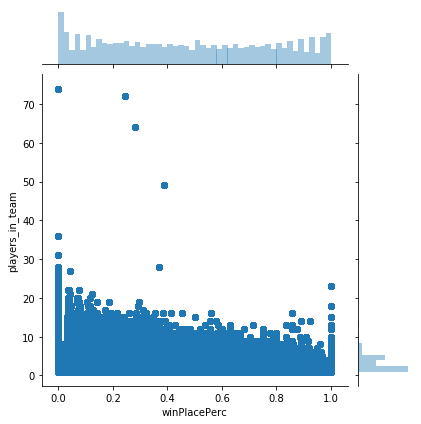

```python
#lets see the correlation players in team with winplaceperc
sns.jointplot(y='players_in_team',x='winPlacePerc',data=train)
plt.show()
```

```python
print("How much does Number of players in a team impact on wining the game =",train['winPlacePerc'].corr(train['players_in_team']))
```

```
How much does Number of players in a team impact on wining the game = -0.29311116498305745
```

As, we can see the impact is negative..So, we need not to worry about number of players in team 🙂😁

```python
train.drop(train.loc[train['players_in_team']].index,inplace=True)
```

# The Killers

> *Pubg is a shooting game🚷🔫..So lets starts with killing features then we will see its correlation with target WinPlacePerc*

1. Headshot kills- killing by aiming on head.
2. Road Kills - killing from vehicles.
3. Longestkills- killing from long distance,generally by snipers.
4. Regular kills- without road kills and headshots.

Lets explore them to find outliers to remove..

[figure not shown]

```python
# Summary statistics for the number of kills
print('The average person kills {:.4f} players'.format(train['kills'].mean()))
print('50% of people have ',train['kills'].quantile(0.50),' kills or more')
print('75% of people have ',train['kills'].quantile(0.75),' kills or more')
print('99% of people have ',train['kills'].quantile(0.99),' kills or more')
print('While the most kills recorded in the training data is', train['kills'].max())
```

```
The average person kills 0.9248 players
50% of people have  0.0  kills or more
75% of people have  1.0  kills or more
99% of people have  7.0  kills or more
While the most kills recorded in the training data is 72
```

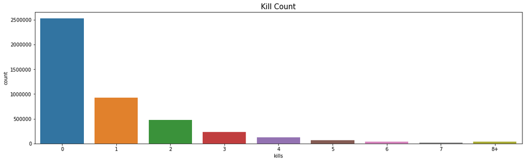

```python
data = train.copy()
data.loc[data['kills'] > data['kills'].quantile(0.99)] = '8+'
plt.figure(figsize = (18, 5))
sns.countplot(data['kills'].astype('str').sort_values())
plt.title('Kill Count',fontsize=15)
plt.show()
```

```python
mostkill=train.loc[train['kills']>50]
mostkill.groupby('Id')['matchType'].first().value_counts()
```

```
normal-solo-fpp     8
normal-duo-fpp      2
normal-squad-fpp    2
normal-squad        1
Name: matchType, dtype: int64
```

We can see that players in normal solo/duo/squad arcade mode kills more then 50 enemy compare to classic matchs .. killing more then 50 may be killing zombies..

**Headshots kills**

[figure not shown]

```python
print("Number of players having headshots equal to total kills:",len(train.loc[(train['headshotKills']>0)&(train['headshotKills']==train['kills'])]))
```

```
Number of players having headshots equal to total kills: 254066
```

Having headshot kills equal to total kills are not seem tome as outliers..but i can say them as acurate shoot players doing maximum damage to enemy👍👍❤️️

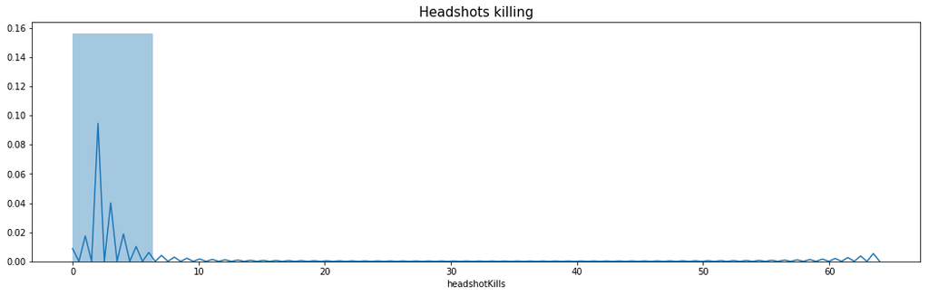

```python
plt.figure(figsize = (18, 5))
sns.distplot(train['headshotKills'],bins=10)
plt.title('Headshots killing',fontsize=15)

plt.show()
```

```python
headshotkill=train.loc[(train['headshotKills']>0)]
headshotkill.groupby('Id')['matchType'].first().value_counts()
```

```
squad-fpp           297143
duo-fpp             169656
solo-fpp             98204
squad                97760
duo                  49305
solo                 29123
normal-squad-fpp      5989
normal-duo-fpp        1265
normal-solo-fpp        941
crashfpp               423
flaretpp               359
normal-squad           252
normal-solo            202
flarefpp               122
normal-duo              77
crashtpp                20
Name: matchType, dtype: int64
```

```python
print("correlation of headshot kills with winning game:",train['winPlacePerc'].corr(train['headshotKills']))
```

```
correlation of headshot kills with winning game: 0.27772154397455834
```

27.77% headshot impact winning game is good..

**Road kills**

[figure not shown]

```python
print("Number of players having roadkills equal to total kills:",len(train.loc[(train['roadKills']>0)&(train['roadKills']==train['kills'])]))
```

```
Number of players having roadkills equal to total kills: 5516
```

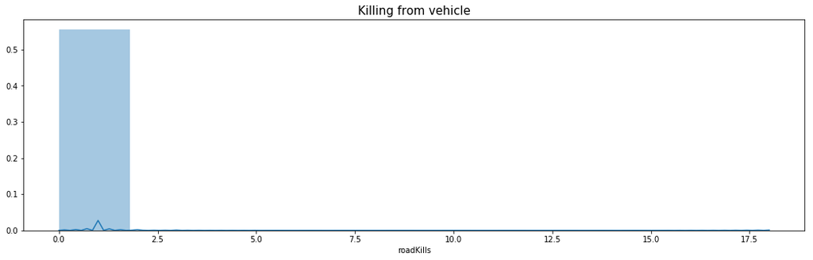

```python
plt.figure(figsize=(18,5))
sns.distplot(train['roadKills'],bins=10)
plt.title('Killing from vehicle',fontsize=15)
plt.show()
```

```python
roadkill=train.loc[(train['roadKills']>0)]
roadkill.groupby('Id')['matchType'].first().value_counts()
```

```
squad-fpp           3061
squad               2362
solo-fpp            1797
duo-fpp             1789
solo                1519
crashfpp            1151
duo                 1112
crashtpp              67
normal-squad-fpp      53
normal-duo-fpp        39
flaretpp              24
normal-squad           8
normal-duo             6
flarefpp               5
normal-solo-fpp        3
Name: matchType, dtype: int64
```

As we can see crash carnige match has roadkills= 1218 as in this match basically killing opponent while being in vehicle.

```python
print("correlation of road kills with wining game:",train['winPlacePerc'].corr(train['roadKills']))
```

```
correlation of road kills with wining game: 0.03454387477694507
```

Roadkill doesnot appear to be much effecting winning of game as number of players done roadkills are very less compare to whole dataset due to inaccurate aim from vehicle..

But Driving over opponent is fun ❌🙎‍♂️🚙.Somethimes in zombies match its fun to kill zombies by vehicles..🧟🧟🚗🚷..

**Longest kill** Maximum longest kill by sniper is 1km..

```python
display(train[['longestKill']].describe())
```

|  | longestKill |
| --- | --- |
| count | 4.446931e+06 |
| mean | NaN |
| std | NaN |
| min | 0.000000e+00 |
| 25% | 0.000000e+00 |
| 50% | 0.000000e+00 |
| 75% | 2.131250e+01 |
| max | 1.094000e+03 |

```python
train['longestKill'].corr(train['headshotKills'])
```

```
0.44725856211433274
```

Yeah most of longest kills are done by headshots ,whearas others by bombs or simple shots

```python
print("No. of players take headshots of enemy more then 1km away:",len(train.loc[train['longestKill']>1000]))
```

```
No. of players take headshots of enemy more then 1km away: 21
```

This 21 people are outliers as more then 1km is not possible.. lets remove them

```python
train.drop(train.loc[train['longestKill']>1000].index,inplace=True)
print("Cheaters deleted")
```

```
Cheaters deleted
```

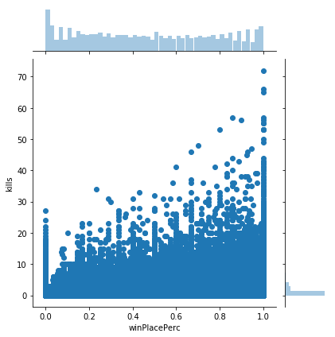

```python
#lets see the correlation kills with winplaceperc
sns.jointplot(y='kills',x='winPlacePerc',data=train)
plt.show()
```

```python
print("How much does killing impact on wining the game =",train['winPlacePerc'].corr(train['kills']))
```

```
How much does killing impact on wining the game = 0.41995535428253616
```

We can see that impact of kills on wining a game is good by 41.99% percentage 👍👏

# Heals and Boosts 🤒

In Playerunknowns battlegrounds, every player has a maximum health of 100%, which can be seen at the bottom of the screen. As the player takes damage, the health bar will decrease and gradually turn red in colour. There are two ways to heal your character after taking damage.

*You can either use boost items which heal over time or instant heal items like first aid kits

To live longer till top 5 alive, its important apply heals and boost.

```python
print("On average players used boosts:{0:5.2f} times".format(train['boosts'].mean()))
print("99% players used boosts:{0:5.2f} times".format(train['boosts'].quantile(0.99)))
print("Maximum boost applied:",train['boosts'].max())
print("\n")
print("On average players used heals:{0:5.2f} times".format(train['heals'].mean()))
print("99% players used heals:{0:5.2f} times".format(train['heals'].quantile(0.99)))
print("Maximum heals applied:",train['heals'].max())
```

```
On average players used boosts: 1.11 times
99% players used boosts: 7.00 times
Maximum boost applied: 33


On average players used heals: 1.37 times
99% players used heals:12.00 times
Maximum heals applied: 80
```

Can't you think applying that much time of boost and heals(max boost 33 times and heals 80 times) is a player who kills or knocks enimies from point blank range or without any safety elements liks helmet, vest or without hiding.. look at there damageDealt its show how casually he played

Lets see who are they....

```python
train.loc[(train['boosts']==33) | (train['heals']==80)]
```

|  | Id | groupId | matchId | assists | boosts | damageDealt | DBNOs | headshotKills | heals | killPlace | ... | rideDistance | roadKills | swimDistance | teamKills | vehicleDestroys | walkDistance | weaponsAcquired | winPoints | winPlacePerc | players_in_team |
| --- | --- | --- | --- | --- | --- | --- | --- | --- | --- | --- | --- | --- | --- | --- | --- | --- | --- | --- | --- | --- | --- |
| 450791 | 5b0d0f8b2d5aab | 35008a7f1ec1a2 | dd814381c28540 | 0 | 33 | 787.5 | 6 | 3 | 3 | 1 | ... | 0.0 | 0 | 0.0 | 0 | 0 | 2790.0 | 5 | 1531 | 0.935547 | 1 |
| 4262661 | 3be1ded892f443 | 5c6c4e66418c25 | ce09de37cf3f5a | 0 | 1 | 230.0 | 5 | 0 | 80 | 41 | ... | 3368.0 | 0 | 0.0 | 0 | 0 | 932.5 | 4 | 1527 | 0.759766 | 4 |

2 rows × 30 columns

I can't treat them(id=5b0d0f8b2d5aab and 3be1ded892f443), who uses max boost and heals as Anomaly as except this two things everything looking fine and they contribute well towards winplaceperc.

Although according to me its not a safe to play like this🤦🤦..

Lets combine heals and boost into one feature and see how they impact on winning the game..

```python
health=train.copy()
health['healsandboosts']=health['heals']+health['boosts']
```

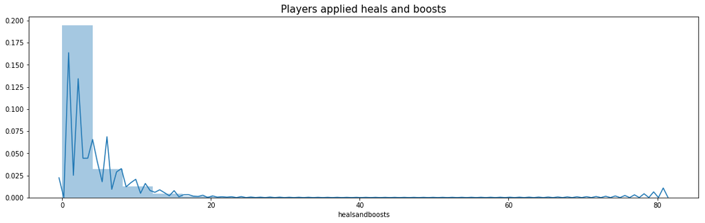

```python
plt.figure(figsize=(18,5))
sns.distplot(health['healsandboosts'],bins=20)
plt.title('Players applied heals and boosts',fontsize=15)
plt.show()
```

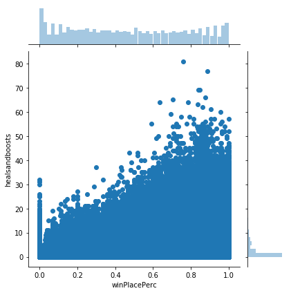

```python
sns.jointplot(y='healsandboosts',x='winPlacePerc',data=health)
plt.show()
```

```python
print("The impact of appling heals and boost to win the game:",health['healsandboosts'].corr(health['winPlacePerc']))
```

```
The impact of appling heals and boost to win the game: 0.5759995165874834
```

As by correlation we can see that to live longer to win the game, its important apply heals and boost. Since, who survies tills last wins and inorder to survie u must use heals and boost...💪🏆

# Weapons Acquired💣🔫🏹

According to [PUBG wiki](https://pubg.gamepedia.com/About) ...

There are different types of weapons like Sniper rifles,

- LMGs,
- SMGs,
- Shotguns,
- Bows,
- Pistols,
- Grenades and
- Melee weapons

> How many weapons can the player hold?

Depending on the players gear (vest 1 - 3 and backpack 1 - 3) you can hold as much as you can carry in your slots. A player can hold 2 primary weapons, 1 pistol, 1 melee weapon and grenades.

[figure not shown]

```python
print("On average players aquired :{0:5.2f} weapons".format(train['weaponsAcquired'].mean()))
print("Maximum weapon acquired:",train['weaponsAcquired'].max())
```

```
On average players aquired : 3.66 weapons
Maximum weapon acquired: 236
```

As in average most of players hold 3 weapons..it can be 2 primary weapons and 1pistol.. or if 3 to 20 weapons acquired then it may be 2 rifles ,1 pistol and others 10 will smoke grenades or frag grenades..

```python
display(train.loc[(train['weaponsAcquired']>=60)&(train['walkDistance']==0),('matchType','weaponsAcquired','walkDistance','winPlacePerc')])
```

|  | matchType | weaponsAcquired | walkDistance | winPlacePerc |
| --- | --- | --- | --- | --- |
| 922608 | normal-solo-fpp | 65 | 0.0 | 0.972168 |
| 1150900 | normal-solo-fpp | 66 | 0.0 | 0.666504 |
| 1358435 | normal-solo-fpp | 69 | 0.0 | 0.428711 |
| 2776847 | normal-solo-fpp | 65 | 0.0 | 0.500000 |
| 2785885 | normal-solo-fpp | 64 | 0.0 | 0.888672 |
| 3062787 | normal-solo-fpp | 63 | 0.0 | 0.866699 |
| 3412134 | normal-solo | 66 | 0.0 | 1.000000 |
| 4082509 | normal-duo-fpp | 68 | 0.0 | 1.000000 |
| 4193346 | normal-squad-fpp | 63 | 0.0 | 0.856934 |

Acquring more then 60 weapons without moving is not possible so removing them

```python
train.drop(train.loc[(train['weaponsAcquired']>=60)&(train['walkDistance']==0)].index, inplace = True)
print("cheaters deleted")
```

```
cheaters deleted
```

```python
display(train.loc[(train['weaponsAcquired']>=90)&(train['walkDistance']<1000)&(train['rideDistance']==0),('matchType','weaponsAcquired','walkDistance','rideDistance', 'roadKills', 'swimDistance','winPlacePerc')])
```

|  | matchType | weaponsAcquired | walkDistance | rideDistance | roadKills | swimDistance | winPlacePerc |
| --- | --- | --- | --- | --- | --- | --- | --- |
| 1449293 | squad-fpp | 95 | 653.0 | 0.0 | 0 | 0.0 | 0.560059 |
| 2373240 | normal-solo-fpp | 96 | 276.0 | 0.0 | 0 | 0.0 | 0.000000 |
| 2442962 | squad-fpp | 95 | 807.5 | 0.0 | 0 | 0.0 | 0.500000 |

Acquiring more then 90 weapons in less then 1km walk distance is also not possible..so removing them

```python
train.drop(train.loc[(train['weaponsAcquired']>=90)&(train['walkDistance']<1000)&(train['rideDistance']==0)].index, inplace = True)
print("cheaters deleted")
```

```
cheaters deleted
```

Lets see the impact of carrying more weapons on winning the game

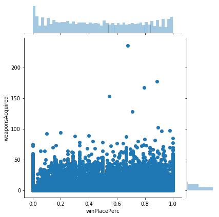

```python
sns.jointplot('winPlacePerc','weaponsAcquired',data=train)
plt.show()
```

```python
print("The impact of carrying more weapons to win the game:",train['weaponsAcquired'].corr(train['winPlacePerc']))
```

```
The impact of carrying more weapons to win the game: 0.584576097122193
```

This shows that without weapons you can't win the game..If you carry more weapons like 2 rifles 1 pistol and many smoke grenades to escape,many Stun grenades to blind enemy,many Molotov cocktail to stop enemies and many Frag grenades to kill hidden enemies, will be helpfull in winning the game. 💣💣🏹🔫

# Knocking and reviving🤝

PUBG game play in squad and duo is all about helping teammates(duo and squad) and with the help of them you can win the game..

in short its a teamwork 👫👬🤝🤝

```python
for_teamwork=train.copy()
mapper = lambda x: 'solo' if ('solo' in x) else 'team'
for_teamwork['matchType'] = for_teamwork['matchType'].apply(mapper)
```

```python
teamonly=for_teamwork.loc[for_teamwork['matchType']=='team']
teamonly['knock_revive']=teamonly['DBNOs']+teamonly['assists']
print("How well  teamwork relate to winning the game:",teamonly['knock_revive'].corr(teamonly['winPlacePerc']))
```

```
How well  teamwork relate to winning the game: 0.3916119278851811
```

Well its only 39% ..its great ..but we have solos also so this cannot be added as column in training set

# The Travellers 🏃‍♂️🚶‍♂️🏊‍♀️🚴‍♂️🚙

[In the Discussion fourm the author says](https://www.kaggle.com/c/pubg-finish-placement-prediction/discussion/67742) The dataset which we have is from any of the map..

Generally people plays 8x8km map like Erangel and vikendi..

[figure not shown]

This is erangel map having 8 x 8 km dimensions.. each yellow box is 1 km

[figure not shown]

```python
#Lets get detail on distance travelled
display(train[['walkDistance','swimDistance','rideDistance']].describe())
```

|  | walkDistance | swimDistance | rideDistance |
| --- | --- | --- | --- |
| count | 4446898.000 | 4446898.0 | 4.446898e+06 |
| mean | NaN | NaN | NaN |
| std | NaN | NaN | NaN |
| min | 0.000 | 0.0 | 0.000000e+00 |
| 25% | 155.125 | 0.0 | 0.000000e+00 |
| 50% | 685.500 | 0.0 | 0.000000e+00 |
| 75% | 1976.000 | 0.0 | 1.913147e-01 |
| max | 25776.000 | 3824.0 | 4.070400e+04 |

Lets check them in dataset

```python
display(train.loc[(train['walkDistance']==1.625000e+04) | (train['swimDistance']==3.823000e+03) | (train['rideDistance']==3.767000e+04)])
```

|  | Id | groupId | matchId | assists | boosts | damageDealt | DBNOs | headshotKills | heals | killPlace | ... | rideDistance | roadKills | swimDistance | teamKills | vehicleDestroys | walkDistance | weaponsAcquired | winPoints | winPlacePerc | players_in_team |
| --- | --- | --- | --- | --- | --- | --- | --- | --- | --- | --- | --- | --- | --- | --- | --- | --- | --- | --- | --- | --- | --- |
| 1227362 | a33e917875c80e | 5b72674b42712b | 5fb0d8b1fc16cf | 0 | 1 | 589.000000 | 3 | 1 | 1 | 46 | ... | 0.0000 | 0 | 3824.000 | 0 | 0 | 995.5 | 9 | 0 | 1.000000 | 8 |
| 1725337 | 9f14f77b6dd9b6 | 8a2a8ae2506323 | 904b5fa7f59bc5 | 0 | 2 | 2.388672 | 0 | 0 | 5 | 19 | ... | 37664.0000 | 0 | 0.000 | 0 | 0 | 542.0 | 2 | 1565 | 0.694336 | 1 |
| 1797162 | 7b9a750b17e9c6 | 2d00192e4029c5 | 6fe77402ddb0e1 | 0 | 0 | 0.000000 | 0 | 0 | 0 | 55 | ... | 0.0401 | 0 | 129.375 | 0 | 0 | 16248.0 | 3 | 0 | 0.600098 | 4 |

3 rows × 30 columns

```python
display(train.loc[(train['walkDistance']==0) & ((train['rideDistance']==0) &(train['swimDistance']==0))&(train['weaponsAcquired']!=0),('walkDistance','rideDistance','swimDistance','weaponsAcquired','matchType')].head())
```

|  | walkDistance | rideDistance | swimDistance | weaponsAcquired | matchType |
| --- | --- | --- | --- | --- | --- |
| 711 | 0.0 | 0.0 | 0.0 | 1 | duo-fpp |
| 846 | 0.0 | 0.0 | 0.0 | 6 | solo |
| 1357 | 0.0 | 0.0 | 0.0 | 15 | solo |
| 1433 | 0.0 | 0.0 | 0.0 | 1 | solo-fpp |
| 1814 | 0.0 | 0.0 | 0.0 | 1 | solo-fpp |

But the above results shows players having more then 5 weapons this is anomaly in solo.. This is anomalies..

```python
train.drop(train.loc[(train['walkDistance']==0) & ((train['rideDistance']==0) &(train['swimDistance']==0))&(train['weaponsAcquired']>5)&(train['matchType']=='solo')].index,inplace=True)
print('Cheaters deleted')
```

```
Cheaters deleted
```

**By foot**

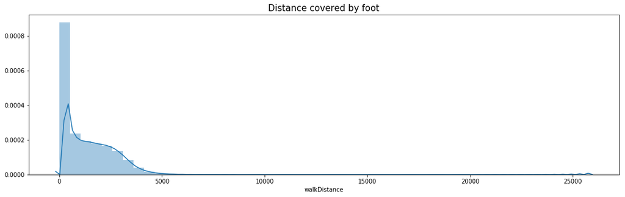

```python
# distribution of walkDistance
plt.figure(figsize=(18,5))
sns.distplot(train['walkDistance'], bins=50)
plt.title("Distance covered by foot",fontsize=15)
plt.show()
```

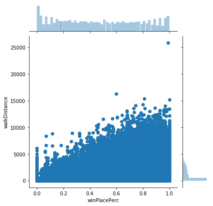

```python
sns.jointplot('winPlacePerc','walkDistance',data=train)
```

```python
print("How well is association between walkingdistance and winning of game:",train['winPlacePerc'].corr(train['walkDistance']))
```

```
How well is association between walkingdistance and winning of game: 0.8111221236008196
```

This is really fantastic to see how walking distance has influence on winning the game..🏃‍♂️🚶‍♂️

**Swimmers**🏊‍♀️

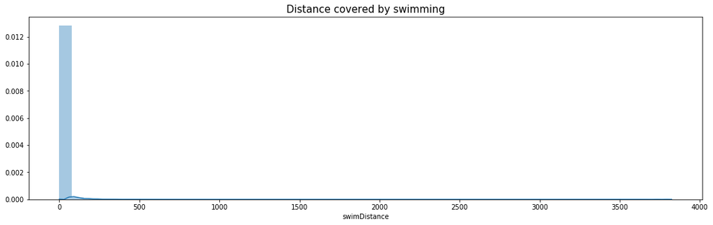

```python
# distribution of swimDistance
plt.figure(figsize=(18,5))
sns.distplot(train['swimDistance'], bins=50)
plt.title("Distance covered by swimming",fontsize=15)
plt.show()
```

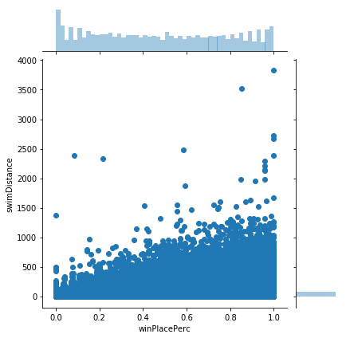

```python
sns.jointplot('winPlacePerc','swimDistance',data=train)
```

```python
print("How well is association between swimming and winning of game:",train['winPlacePerc'].corr(train['swimDistance']))
```

```
How well is association between swimming and winning of game: 0.14963058599988016
```

This is obviousDictionary u can't win the game in water as u can't kill in water and circle doesn't made on water

**The Riders**🚙🚴‍♂️

[figure not shown]

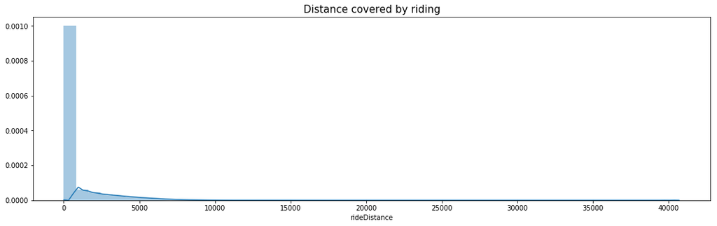

```python
# distribution of swimDistance
plt.figure(figsize=(18,5))
sns.distplot(train['rideDistance'], bins=50)
plt.title("Distance covered by riding",fontsize=15)
plt.show()
```

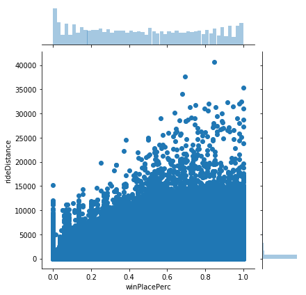

```python
sns.jointplot('winPlacePerc','rideDistance',data=train)
```

```python
print("How well is association between riding and winning of game:",train['winPlacePerc'].corr(train['rideDistance']))
```

```
How well is association between riding and winning of game: 0.34296271344334595
```

its good to see 34%..this is mostly due to crash carnage modes there u need to only ride to reach finals

# Feature engineering

Some of the feature engineering we have seen earlier are-

- No.of players per groupid
- heals and boosts

```python
headshot = train[['kills','winPlacePerc','headshotKills']]
headshot['headshotrate'] = headshot['kills'] / headshot['headshotKills']
headshot.corr()
```

|  | kills | winPlacePerc | headshotKills | headshotrate |
| --- | --- | --- | --- | --- |
| kills | 1.000000 | 0.420073 | 0.674219 | 0.678922 |
| winPlacePerc | 0.420073 | 1.000000 | 0.277764 | 0.323764 |
| headshotKills | 0.674219 | 0.277764 | 1.000000 | -0.082737 |
| headshotrate | 0.678922 | 0.323764 | -0.082737 | 1.000000 |

```python
killStreak = train[['kills','winPlacePerc','killStreaks']]
killStreak['killStreakrate'] = killStreak['killStreaks']/killStreak['kills']
killStreak.corr()
```

|  | kills | winPlacePerc | killStreaks | killStreakrate |
| --- | --- | --- | --- | --- |
| kills | 1.000000 | 0.420073 | 0.802632 | -0.731109 |
| winPlacePerc | 0.420073 | 1.000000 | 0.377540 | -0.386685 |
| killStreaks | 0.802632 | 0.377540 | 1.000000 | -0.143839 |
| killStreakrate | -0.731109 | -0.386685 | -0.143839 | 1.000000 |

```python
kills = train[['assists','kills','winPlacePerc']]
kills['kills_assists'] = (kills['kills'] + kills['assists'])
kills.corr()
```

|  | assists | kills | winPlacePerc | kills_assists |
| --- | --- | --- | --- | --- |
| assists | 1.000000 | 0.319310 | 0.299517 | 0.592523 |
| kills | 0.319310 | 1.000000 | 0.420073 | 0.952581 |
| winPlacePerc | 0.299517 | 0.420073 | 1.000000 | 0.453257 |
| kills_assists | 0.592523 | 0.952581 | 0.453257 | 1.000000 |

## WINNER WINNER CHICKEN DINNER

[figure not shown]